# Bot

### Теперь посмотрим на возраст + цвета

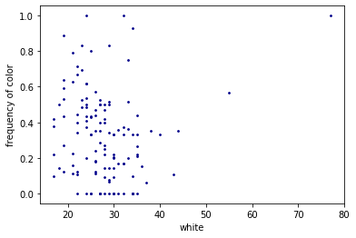

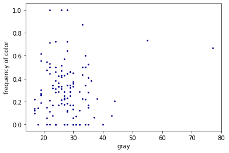

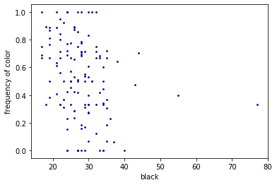

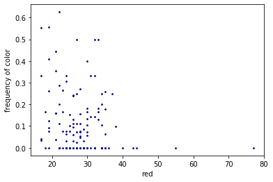

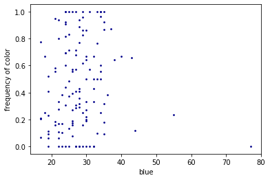

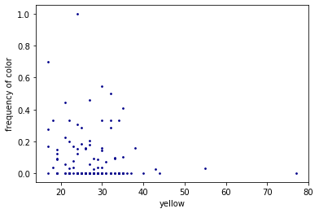

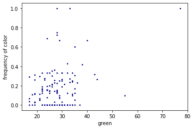

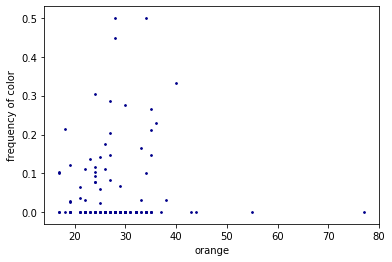

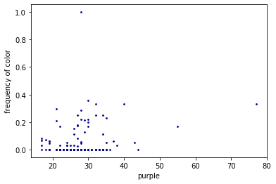

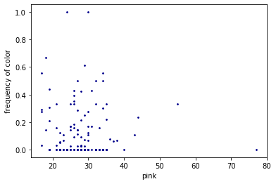

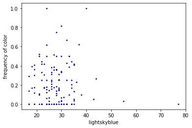

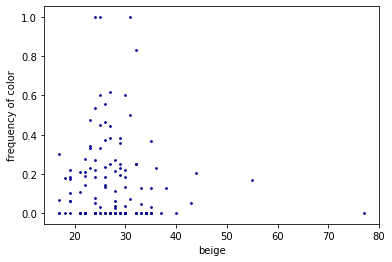

[6 more figures not shown]

```python
for color in colors:
    plt.scatter(df_freqs['age'], df_freqs[color], color='darkblue', s=3)
    plt.xlabel(color)
    plt.ylabel('frequency of color')
    plt.show()
```

### Здесь мы посчитаем ранговую корреляцию Спирмена, потому что распределения возрастов и частоты цветов в ответах пользователя не нормальны

```
coral           : coef = 0.004, p = 0.961
lightskyblue    : coef = 0.012, p = 0.894
gray            : coef = -0.017, p = 0.853
pink            : coef = -0.018, p = 0.841
maroon          : coef = 0.034, p = 0.702
mediumturquoise : coef = 0.043, p = 0.629
orange          : coef = -0.066, p = 0.457
orchid          : coef = 0.071, p = 0.428
purple          : coef = 0.084, p = 0.348
greenyellow     : coef = -0.105, p = 0.238
beige           : coef = -0.131, p = 0.140
saddlebrown     : coef = 0.133, p = 0.135
green           : coef = 0.152, p = 0.087
blue            : coef = 0.157, p = 0.077
yellow          : coef = -0.166, p = 0.061
red             : coef = -0.174, p = 0.049
white           : coef = -0.253, p = 0.004
black           : coef = -0.324, p = 0.000
```

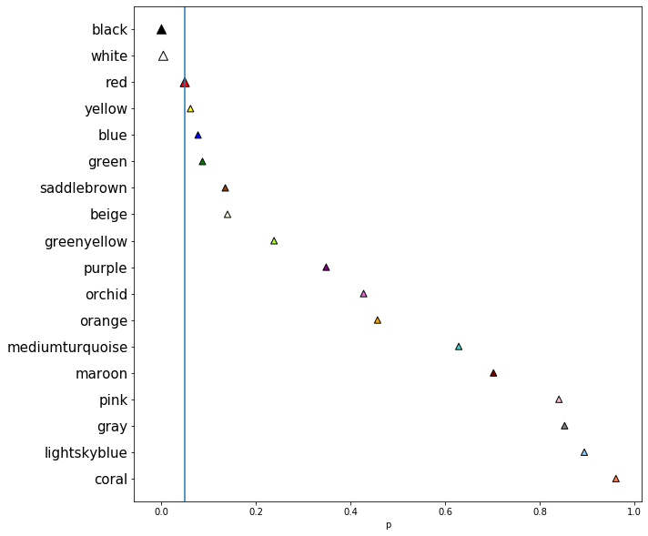

```python
colors_diffs_in_age = []

for color in colors:
    coef, p = spearmanr(df_freqs['age'], df_freqs[color])
    colors_diffs_in_age.append((color, coef, p))

colors_diffs_in_age.sort(key=lambda x: -x[2])

for record in colors_diffs_in_age:
    print(f'{record[0]:<16}: coef = %.3f, p = %.3f' % (record[1], record[2]))


fig, ax = plt.subplots(figsize=(10, 10))
ax.scatter([record[2] for record in colors_diffs_in_age],
           [record[0] for record in colors_diffs_in_age],
           edgecolor='black',
           color=[x[0] for x in colors_diffs_in_age],
           marker='^',
           s=[100 if x[2] < alpha else 50 for x in colors_diffs_in_age])
ax.axvline(x=alpha)
ax.set_yticklabels([x[0] for x in colors_diffs_in_age],
                   fontsize = 15)
plt.xlabel('p')
plt.show()
```

### Красный, белый и черный. Чем старше человек, тем меньше драматичности в его одежде! Но есть версия, что на результат могли повлить выбросы. Раз уж красный цвет буквально ходит по грани, попробуем от них избавиться и проделать все то же самое.

```python
df_freqs_new = df_freqs[df_freqs['age'] < 50]
df_freqs_new.shape
```

```
(126, 23)
```

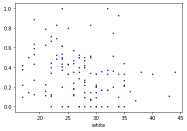

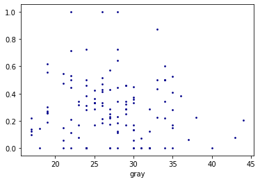

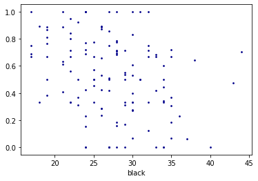

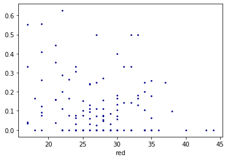

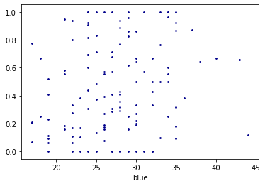

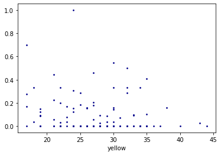

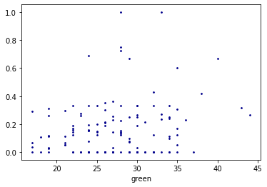

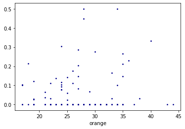

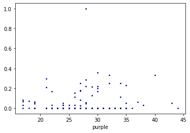

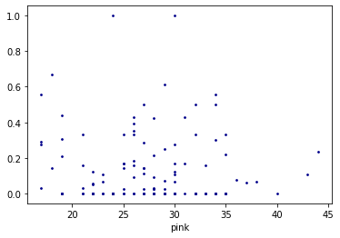

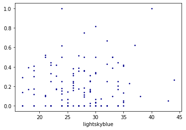

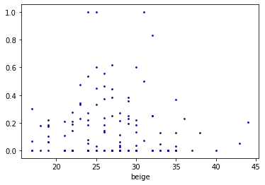

[6 more figures not shown]

```python
for color in colors:
    plt.scatter(df_freqs_new['age'], df_freqs_new[color], color='darkblue', s=3)
    plt.xlabel(color)
    plt.show()
```

```
mediumturquoise : coef = 0.023, p = 0.799
pink            : coef = -0.023, p = 0.797
coral           : coef = -0.032, p = 0.726
lightskyblue    : coef = 0.038, p = 0.674
purple          : coef = 0.039, p = 0.669
maroon          : coef = 0.042, p = 0.643
orange          : coef = -0.049, p = 0.586
orchid          : coef = 0.053, p = 0.559
gray            : coef = -0.061, p = 0.495
greenyellow     : coef = -0.098, p = 0.274
beige           : coef = -0.125, p = 0.162
saddlebrown     : coef = 0.136, p = 0.129
green           : coef = 0.137, p = 0.125
red             : coef = -0.150, p = 0.095
yellow          : coef = -0.166, p = 0.063
blue            : coef = 0.192, p = 0.032
white           : coef = -0.304, p = 0.001
black           : coef = -0.316, p = 0.000
```

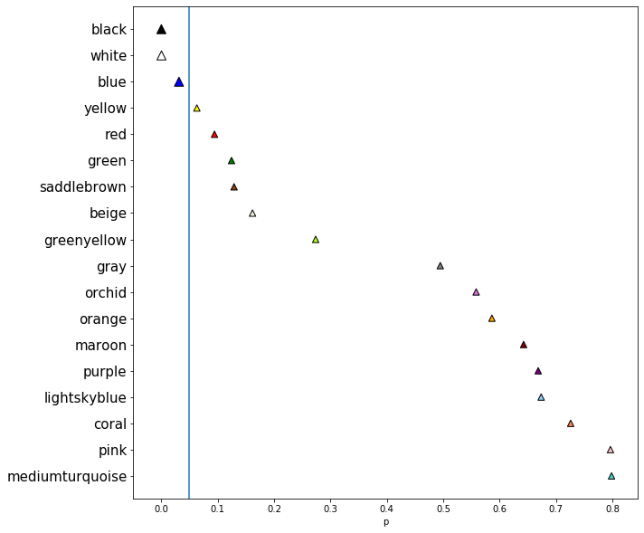

```python
colors_diffs_in_age_new = []

for color in colors:
    coef, p = spearmanr(df_freqs_new['age'], df_freqs_new[color])
    colors_diffs_in_age_new.append((color, coef, p))

colors_diffs_in_age_new.sort(key=lambda x: -x[2])

for record in colors_diffs_in_age_new:
    print(f'{record[0]:<16}: coef = %.3f, p = %.3f' % (record[1], record[2]))


fig, ax = plt.subplots(figsize=(10, 10))
ax.scatter([record[2] for record in colors_diffs_in_age_new],
           [record[0] for record in colors_diffs_in_age_new],
           edgecolor='black',
           color=[x[0] for x in colors_diffs_in_age_new],
           marker='^',
           s=[100 if x[2] < alpha else 50 for x in colors_diffs_in_age_new])
ax.axvline(x=alpha)
ax.set_yticklabels([x[0] for x in colors_diffs_in_age_new],
                   fontsize = 15)
plt.xlabel('p')
plt.show()
```

### Результаты и правда поменялись! Черный и белый все так же привлекают молодежь, а вот красный сменился синим, причем с другим знаком.

### Теперь посмотрим на сочетания цветов.

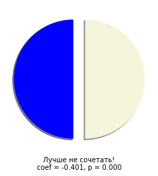

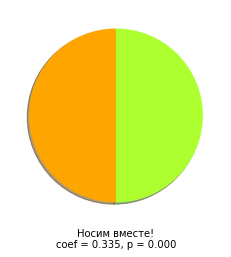

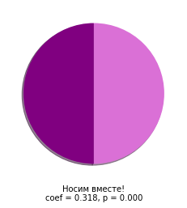

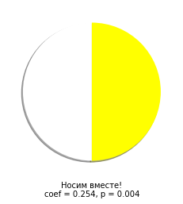

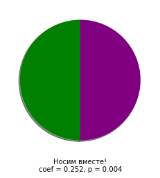

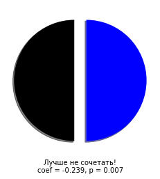

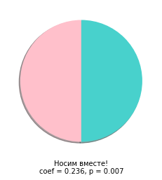

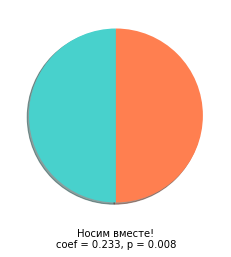

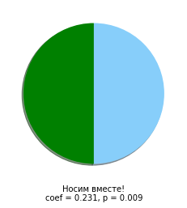

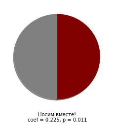

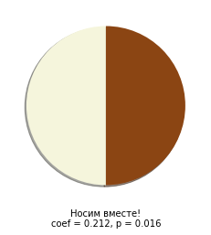

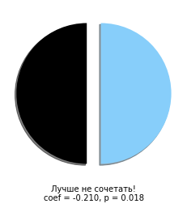

[10 more figures not shown]

```python
import itertools
colors_together = []

results = []
for pair in itertools.combinations(colors, 2):
    coef, p = spearmanr(df_freqs[pair[0]], df_freqs[pair[1]])
    if p < alpha:
        colors_together.append((pair, coef, p))

colors_together.sort(key=lambda x: x[2])

for record in colors_together:
    comment_string = 'Носим вместе!\n' if record[1] > 0 else 'Лучше не сочетать!\n'
    explode = [0.1] * 2 if record[1] < 0 else None
    plt.pie([1, 1], colors=record[0], shadow=True, startangle=90, explode=explode)
    plt.xlabel(comment_string + 'coef = %.3f, p = %.3f' % (record[1], record[2]))
    plt.show()
```

### Модные сочетания: носим оранжевый с салатовый, а фиолетовый с сиреневым. Избегаем синего с бежевым и белым! То, что черный отрицательно связан с синим и голубым, думаю, связано с тремя основными цветами джинсов.

### Просто ради любопытства посмотрим для всех цветов, как меняется вероятность их встретить при условии, что какой-то другой цвет мы уже надели

```python
results = []
for pair in itertools.permutations(colors, 2):
    p_color1 = df[pair[1]].sum() / df.shape[0]
    df_color0 = df[df[pair[0]] == 1]
    p_color1_cond = df_color0[pair[1]].sum() / df_color0.shape[0]
    if abs(p_color1 - p_color1_cond) >= 0.15:
        print(f'{pair[1]}: {round(p_color1, 2)}, with {pair[0]}: {round(p_color1_cond, 2)}')
```

```
white: 0.34, with orange: 0.18
blue: 0.44, with pink: 0.28
blue: 0.44, with beige: 0.26
gray: 0.31, with orchid: 0.11
black: 0.52, with mediumturquoise: 0.3
black: 0.52, with coral: 0.24
blue: 0.44, with greenyellow: 0.06
pink: 0.13, with greenyellow: 0.32
```

### Заметим, что второй (фоновый) цвет при резком изменении вероятности скорее из редких, а первый, для которого вероятность считаем - из "базовых". Многое подтверждается тестами выше.

### К сожалению, для поиска интересного по городам и роду деятельности пока слишком мало представлено разных категорий, потому что мало пользователей, а для адекватного отражения сезонности бот существует слишком мало времени. Попробуем посмотреть на цвета + температуру воздуха в СПб. Температуру возьмем с https://www.gismeteo.ru/diary/

```python
degrees = [5, 6, 4, 4, 7, 4, 6, 3, 7, 6, 11, 19, 11, 7, 9, 12, 15, 15, 12, 12, 4, 13, 8, 6, 5, 5, 4, 5, 7, 12, 9, 7, 5, 3, 8,
           7, 8, 3, 11, 15, 25, 27, 24, 20, 22, 19]

df_spb = df[df['city'] == 'spb']
df_spb.shape
```

```
(1912, 30)
```

```python
df_spb['degrees'] = [degrees[x - 1] for x in df_spb['day_number']]
df_spb
```

|  | user_id | sex | timezone | age | city | occupation | question_time_minutes | white | gray | black | ... | maroon | mediumturquoise | coral | greenyellow | year | month | day | day_number | weekday | degrees |
| --- | --- | --- | --- | --- | --- | --- | --- | --- | --- | --- | --- | --- | --- | --- | --- | --- | --- | --- | --- | --- | --- |
| 0 | 93 | female | 3 | 28.0 | spb | worker | 1320.0 | 0 | 0 | 1 | ... | 0 | 0 | 0 | 0 | 2021 | 4 | 13 | 12 | 1 | 19 |
| 1 | 93 | female | 3 | 28.0 | spb | worker | 1320.0 | 1 | 0 | 1 | ... | 0 | 0 | 0 | 0 | 2021 | 4 | 14 | 13 | 2 | 11 |
| 2 | 93 | female | 3 | 28.0 | spb | worker | 1320.0 | 0 | 1 | 1 | ... | 0 | 0 | 0 | 0 | 2021 | 4 | 15 | 14 | 3 | 7 |
| 3 | 93 | female | 3 | 28.0 | spb | worker | 1320.0 | 0 | 0 | 0 | ... | 0 | 0 | 0 | 0 | 2021 | 4 | 16 | 15 | 4 | 9 |
| 4 | 93 | female | 3 | 28.0 | spb | worker | 1320.0 | 0 | 0 | 1 | ... | 0 | 0 | 0 | 0 | 2021 | 4 | 17 | 16 | 5 | 12 |
| ... | ... | ... | ... | ... | ... | ... | ... | ... | ... | ... | ... | ... | ... | ... | ... | ... | ... | ... | ... | ... | ... |
| 2343 | 57 | female | 3 | 30.0 | spb | worker | 1240.0 | 0 | 0 | 1 | ... | 0 | 0 | 0 | 0 | 2021 | 5 | 16 | 45 | 6 | 22 |
| 2344 | 57 | female | 3 | 30.0 | spb | worker | 1240.0 | 0 | 0 | 0 | ... | 0 | 0 | 0 | 0 | 2021 | 5 | 17 | 46 | 0 | 19 |
| 2345 | 96 | female | 3 | 32.0 | spb | worker | 780.0 | 0 | 0 | 0 | ... | 1 | 0 | 0 | 0 | 2021 | 5 | 14 | 43 | 4 | 24 |
| 2346 | 96 | female | 3 | 32.0 | spb | worker | 780.0 | 0 | 0 | 0 | ... | 1 | 0 | 0 | 0 | 2021 | 5 | 15 | 44 | 5 | 20 |
| 2347 | 96 | female | 3 | 32.0 | spb | worker | 780.0 | 1 | 0 | 1 | ... | 0 | 0 | 0 | 0 | 2021 | 5 | 16 | 45 | 6 | 22 |

1912 rows × 31 columns

```
pink    : coef = -0.002, p = 0.935
orchid  : coef = 0.004, p = 0.848
maroon  : coef = -0.006, p = 0.798
gray    : coef = 0.007, p = 0.763
purple  : coef = 0.008, p = 0.731
yellow  : coef = 0.008, p = 0.717
beige   : coef = 0.011, p = 0.628
mediumturquoise: coef = 0.013, p = 0.579
orange  : coef = -0.017, p = 0.469
blue    : coef = -0.020, p = 0.373
green   : coef = 0.030, p = 0.189
red     : coef = -0.033, p = 0.152
greenyellow: coef = 0.034, p = 0.137
coral   : coef = 0.045, p = 0.051
lightskyblue: coef = 0.048, p = 0.036
saddlebrown: coef = -0.063, p = 0.006
white   : coef = 0.072, p = 0.002
black   : coef = -0.077, p = 0.001
```

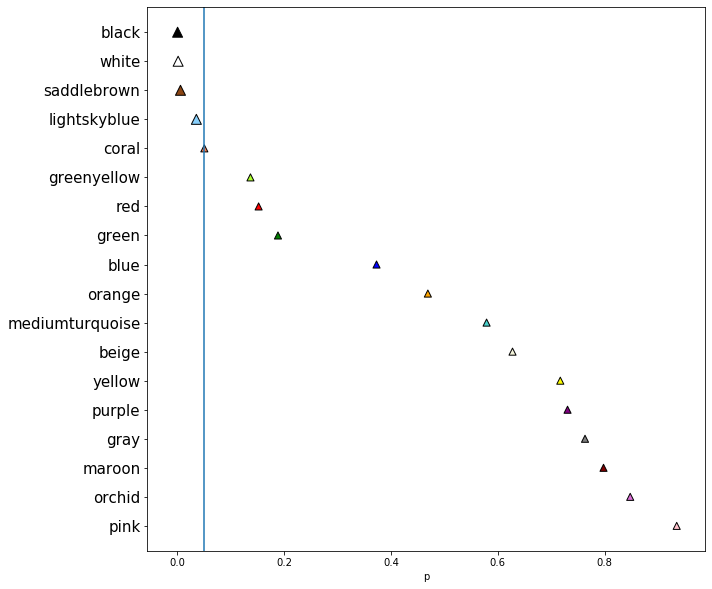

```python
colors_that_diff_when_warm = []

for color in colors:
    coef, p = spearmanr(df_spb['degrees'], df_spb[color])
    colors_that_diff_when_warm.append((color, coef, p))

colors_that_diff_when_warm.sort(key=lambda x: -x[2])

for record in colors_that_diff_when_warm:
    print(f'{record[0]:<8}: coef = %.3f, p = %.3f' % (record[1], record[2]))


fig, ax = plt.subplots(figsize=(10, 10))
ax.scatter([record[2] for record in colors_that_diff_when_warm],
           [record[0] for record in colors_that_diff_when_warm],
           edgecolor='black',
           color=[x[0] for x in colors_that_diff_when_warm],
           marker='^',
           s=[100 if x[2] < alpha else 50 for x in colors_that_diff_when_warm])
ax.axvline(x=alpha)
ax.set_yticklabels([x[0] for x in colors_that_diff_when_warm],
                   fontsize = 15)
plt.xlabel('p')
plt.show()
```

### Что ж, выглядит правдоподобно, хотя корреляции и малы. Черный и коричневый носим меньше, белый и голубой - больше!

### Наконец, посмотрим на выходные и будние дни. В этом году все было сложно с 4-7 мая, поэтому мы их выкинем :)

```python
df_weekends = df[df['weekday'] >= 5]
df_3_10 = df[df['day'] == 3]
df_3_10 = df_3_10[df_3_10['month'] == 5]
df_3_10

df_weekends = pd.concat([df_weekends, df_3_10])
df_weekends
```

|  | user_id | sex | timezone | age | city | occupation | question_time_minutes | white | gray | black | ... | orchid | maroon | mediumturquoise | coral | greenyellow | year | month | day | day_number | weekday |
| --- | --- | --- | --- | --- | --- | --- | --- | --- | --- | --- | --- | --- | --- | --- | --- | --- | --- | --- | --- | --- | --- |
| 4 | 93 | female | 3 | 28.0 | spb | worker | 1320.0 | 0 | 0 | 1 | ... | 0 | 0 | 0 | 0 | 0 | 2021 | 4 | 17 | 16 | 5 |
| 5 | 93 | female | 3 | 28.0 | spb | worker | 1320.0 | 1 | 0 | 1 | ... | 0 | 0 | 0 | 0 | 0 | 2021 | 4 | 18 | 17 | 6 |
| 11 | 93 | female | 3 | 28.0 | spb | worker | 1320.0 | 1 | 0 | 1 | ... | 0 | 0 | 0 | 0 | 0 | 2021 | 4 | 24 | 23 | 5 |
| 12 | 93 | female | 3 | 28.0 | spb | worker | 1320.0 | 0 | 1 | 1 | ... | 0 | 0 | 0 | 0 | 0 | 2021 | 4 | 25 | 24 | 6 |
| 18 | 93 | female | 3 | 28.0 | spb | worker | 1320.0 | 1 | 0 | 1 | ... | 0 | 0 | 0 | 0 | 0 | 2021 | 5 | 1 | 30 | 5 |
| ... | ... | ... | ... | ... | ... | ... | ... | ... | ... | ... | ... | ... | ... | ... | ... | ... | ... | ... | ... | ... | ... |
| 2183 | 68 | female | 2 | 35.0 | other | worker | 735.0 | 0 | 1 | 0 | ... | 0 | 0 | 0 | 0 | 0 | 2021 | 5 | 3 | 32 | 0 |
| 2201 | 63 | female | 3 | 21.0 | spb | worker | 960.0 | 0 | 0 | 1 | ... | 0 | 1 | 0 | 0 | 0 | 2021 | 5 | 3 | 32 | 0 |
| 2218 | 55 | female | 3 | 24.0 | spb | worker | 1200.0 | 0 | 1 | 0 | ... | 0 | 0 | 0 | 0 | 0 | 2021 | 5 | 3 | 32 | 0 |
| 2234 | 33 | female | 2 | 27.0 | other | worker | 780.0 | 1 | 0 | 1 | ... | 1 | 0 | 0 | 0 | 0 | 2021 | 5 | 3 | 32 | 0 |
| 2236 | 0 | female | 3 | 28.0 | spb | worker | 1260.0 | 0 | 1 | 1 | ... | 0 | 0 | 0 | 0 | 0 | 2021 | 5 | 3 | 32 | 0 |

746 rows × 30 columns

```python
df_workdays = df[df['weekday'] < 5]
df_workdays = df_workdays[df_workdays['month'] == 4]

df_march = df[df['month'] == 5]
df_march = df_march[df_march['day'] > 10]
df_march = df_march[df_march['weekday'] < 5]

df_workdays = pd.concat([df_workdays, df_march])
df_workdays
```

|  | user_id | sex | timezone | age | city | occupation | question_time_minutes | white | gray | black | ... | orchid | maroon | mediumturquoise | coral | greenyellow | year | month | day | day_number | weekday |
| --- | --- | --- | --- | --- | --- | --- | --- | --- | --- | --- | --- | --- | --- | --- | --- | --- | --- | --- | --- | --- | --- |
| 0 | 93 | female | 3 | 28.0 | spb | worker | 1320.0 | 0 | 0 | 1 | ... | 0 | 0 | 0 | 0 | 0 | 2021 | 4 | 13 | 12 | 1 |
| 1 | 93 | female | 3 | 28.0 | spb | worker | 1320.0 | 1 | 0 | 1 | ... | 0 | 0 | 0 | 0 | 0 | 2021 | 4 | 14 | 13 | 2 |
| 2 | 93 | female | 3 | 28.0 | spb | worker | 1320.0 | 0 | 1 | 1 | ... | 0 | 0 | 0 | 0 | 0 | 2021 | 4 | 15 | 14 | 3 |
| 3 | 93 | female | 3 | 28.0 | spb | worker | 1320.0 | 0 | 0 | 0 | ... | 1 | 0 | 0 | 0 | 0 | 2021 | 4 | 16 | 15 | 4 |
| 6 | 93 | female | 3 | 28.0 | spb | worker | 1320.0 | 1 | 0 | 1 | ... | 0 | 0 | 0 | 0 | 0 | 2021 | 4 | 19 | 18 | 0 |
| ... | ... | ... | ... | ... | ... | ... | ... | ... | ... | ... | ... | ... | ... | ... | ... | ... | ... | ... | ... | ... | ... |
| 2337 | 26 | male | 3 | 34.0 | spb | worker | 1005.0 | 0 | 1 | 0 | ... | 0 | 0 | 0 | 0 | 0 | 2021 | 5 | 14 | 43 | 4 |
| 2340 | 57 | female | 3 | 30.0 | spb | worker | 1240.0 | 0 | 0 | 0 | ... | 0 | 0 | 0 | 0 | 0 | 2021 | 5 | 13 | 42 | 3 |
| 2341 | 57 | female | 3 | 30.0 | spb | worker | 1240.0 | 0 | 0 | 0 | ... | 0 | 0 | 0 | 0 | 0 | 2021 | 5 | 14 | 43 | 4 |
| 2344 | 57 | female | 3 | 30.0 | spb | worker | 1240.0 | 0 | 0 | 0 | ... | 0 | 0 | 0 | 0 | 0 | 2021 | 5 | 17 | 46 | 0 |
| 2345 | 96 | female | 3 | 32.0 | spb | worker | 780.0 | 0 | 0 | 0 | ... | 0 | 1 | 0 | 0 | 0 | 2021 | 5 | 14 | 43 | 4 |

1323 rows × 30 columns

```python
df_freqs_weekends = df_weekends.groupby('day_number').sum()[colors] / df_weekends.groupby('day_number').count()[colors]
df_freqs_weekends.shape
```

```
(14, 18)
```

```python
df_freqs_workdays = df_workdays.groupby('day_number').sum()[colors] / df_workdays.groupby('day_number').count()[colors]
df_freqs_workdays.shape
```

```
(25, 18)
```

```
green           : stat = 159.000, p = 0.325
orange          : stat = 156.000, p = 0.294
maroon          : stat = 150.500, p = 0.240
greenyellow     : stat = 151.000, p = 0.227
pink            : stat = 147.000, p = 0.210
white           : stat = 146.500, p = 0.206
blue            : stat = 146.000, p = 0.202
red             : stat = 145.500, p = 0.198
mediumturquoise : stat = 144.500, p = 0.185
yellow          : stat = 143.000, p = 0.178
gray            : stat = 142.000, p = 0.171
coral           : stat = 135.000, p = 0.114
lightskyblue    : stat = 129.000, p = 0.091
purple          : stat = 121.000, p = 0.059
saddlebrown     : stat = 118.500, p = 0.051
orchid          : stat = 104.500, p = 0.019
black           : stat = 102.000, p = 0.017
beige           : stat = 82.000, p = 0.003
```

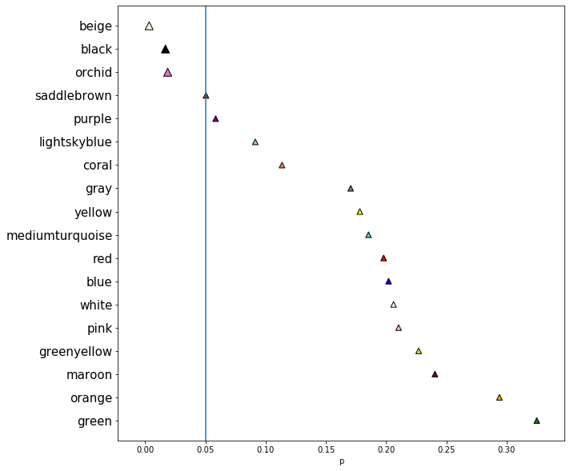

```python
color_diffs = []
alpha = 0.05

for color in colors:
    stat, p = mannwhitneyu(df_freqs_weekends[color], df_freqs_workdays[color])
    color_diffs.append((color, stat, p))

color_diffs.sort(key=lambda x: -x[2])


for record in color_diffs:
    print(f'{record[0]:<16}: stat = %.3f, p = %.3f' % (record[1], record[2]))

fig, ax = plt.subplots(figsize=(10, 10))
ax.scatter([record[2] for record in color_diffs],
           [record[0] for record in color_diffs],
           edgecolor='black',
           color=[x[0] for x in color_diffs],
           marker='^',
           s=[100 if x[2] < alpha else 50 for x in color_diffs])
ax.axvline(x=alpha)
ax.set_yticklabels([x[0] for x in color_diffs],
                   fontsize = 15)
plt.xlabel('p')
plt.show()
```

### Что бы это могло значить? Непонятно. Будем вести наблюдения дальше!